# Proyecto EasyVisa

### Clasificador de Aumento de Gradiente -Ajustado

- La mayoría de los ajustes disponibles para el modelo de aumento de gradiente son los mismos que los que se usan en el modelo de bosque aleatorio.
- El parámetro "init" es como una suposición inicial que se hace antes de comenzar el proceso de entrenamiento. Si se establece en "cero", significa que asumimos que las predicciones iniciales son todas cero. Por defecto, se utiliza un enfoque simple que se basa en las clases previamente observadas para hacer estas suposiciones iniciales.
- A diferencia de algunos otros modelos, el aumento de gradiente no tiene un parámetro llamado "class_weights" que permita asignar pesos diferentes a las clases. Esto significa que todas las clases se tratan de manera igual en términos de importancia durante el entrenamiento del modelo.

```python
## Intentemos usar el clasificador AdaBoost como estimador para las predicciones iniciales**
gbc_init = GradientBoostingClassifier(init=AdaBoostClassifier(random_state=1),random_state=1)
gbc_init.fit(X_train,y_train)
```

```
GradientBoostingClassifier(init=AdaBoostClassifier(random_state=1),
                           random_state=1)
```

##### Revisión del rendimiento en el conjunto de entrenamiento

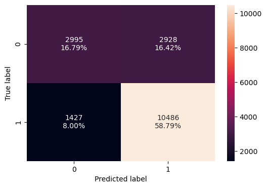

```python
confusion_matrix_sklearn(gbc_init, X_train,y_train)
```

```python
gbc_init_model_train_perf=model_performance_classification_sklearn(abc_tuned, X_train,y_train)
print("Training performance \n",gbc_init_model_train_perf)
```

[output not shown]

##### Revisión del rendimiento en el conjunto de prueba

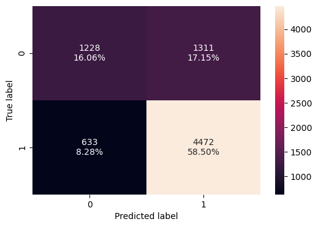

```python
confusion_matrix_sklearn(gbc_init, X_test,y_test)
```

```python
gbc_init_model_test_perf=model_performance_classification_sklearn(gbc_init, X_test, y_test)
print("Testing performance \n",gbc_init_model_test_perf)
```

```
Testing performance
    Accuracy  Recall  Precision    F1
0     0.746   0.876      0.773 0.821
```

##### Agregando hiperparámetros al modelo Aumento de gradiente -Ajustado:

```python
%%time
# Choose the type of classifier.
gbc_tuned = GradientBoostingClassifier(init=AdaBoostClassifier(random_state=1),random_state=1)

# Grid of parameters to choose
parameters = {
    "n_estimators": [100,150,250,300],
    "subsample":[0.8,0.9,1],
    "max_features":[0.7,0.8,0.9,1]
}

# Type of scoring used to compare parameter combinations
acc_scorer = metrics.make_scorer(metrics.f1_score)

# Run the grid search
grid_obj = GridSearchCV(gbc_tuned, parameters, scoring=acc_scorer,cv=5,n_jobs=-1 )
grid_obj = grid_obj.fit(X_train, y_train)

# Set the clf to the best combination of parameters
gbc_tuned = grid_obj.best_estimator_

# Fit the best algorithm to the data.
gbc_tuned.fit(X_train, y_train)
```

```
CPU times: total: 5 s
Wall time: 1min 25s
```

```
GradientBoostingClassifier(init=AdaBoostClassifier(random_state=1),
                           max_features=0.7, random_state=1, subsample=0.8)
```

##### Revisión del rendimiento en el conjunto de entrenamiento

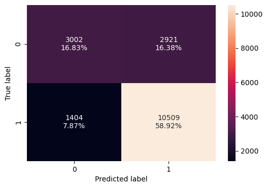

```python
confusion_matrix_sklearn(gbc_tuned, X_train,y_train)
```

```python
gbc_tuned_model_train_perf=model_performance_classification_sklearn(gbc_tuned, X_train,y_train)
print("Training performance \n",gbc_tuned_model_train_perf)
```

```
Training performance
    Accuracy  Recall  Precision    F1
0     0.758   0.882      0.783 0.829
```

##### Revisión del rendimiento en el conjunto de prueba

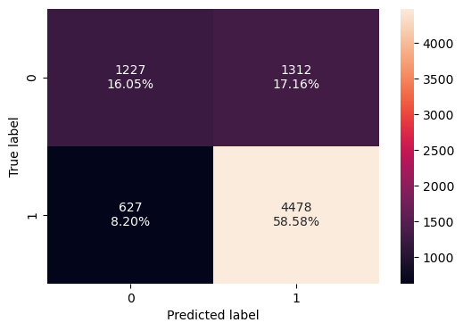

```python
confusion_matrix_sklearn(gbc_tuned, X_test,y_test)
```

```python
gbc_tuned_model_test_perf=model_performance_classification_sklearn(gbc_tuned, X_test, y_test)
print("Testing performance \n",gbc_tuned_model_test_perf)
```

```
Testing performance
    Accuracy  Recall  Precision    F1
0     0.746   0.877      0.773 0.822
```

###### Observaciones Clasificador Aumento de gradiente - ajustado

- El modeloAumento de gradiente ajustado usando el clasificador AdaBoost como estimador para las predicciones iniciales:
- El modelo generaliza los datos de entrenamiento y prueba; este modelo utilizando como ajuste el clasificador AdaBoost como estimador para las predicciones iniciales, no muestra una diferencia con el modelo GB de aumento de gradiente sin ajustar.
- El modelo es más fuerte en Recall (0.88)
- El f1_score, métrica de importancia es de 0.82.
- Del modelo del gradiente potenciado y ajustado con hiperparámetros **gbc_tuned**
- No hay una diferencia significatica con el modelo GB de aumento de gradiente sin ajustar ó el ajustado utilizando el clasificador AdaBoost como estimador para las predicciones iniciales
- Recall se mantiene como la métrica de rendimiento que rige el modelo, el f1_score se mantiene en 0.82
- Es posible que idealmente, ajustando los hiperámetros se pueda mejorar el f1_score para equilibrar más el modelo.**

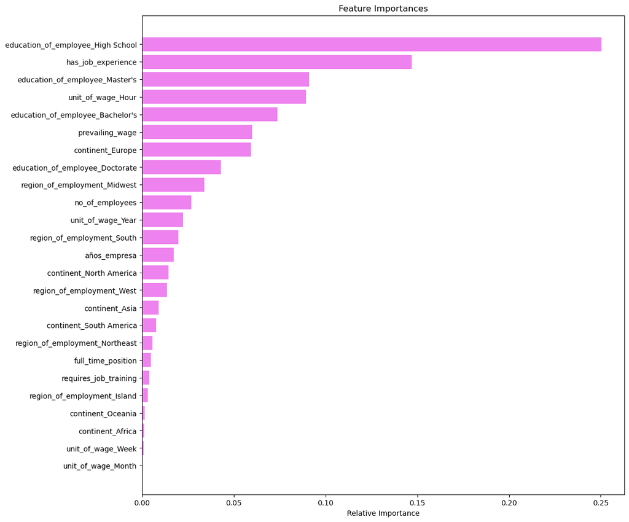

```python
importances = gbc_tuned.feature_importances_
indices = np.argsort(importances)
feature_names = list(X.columns)

plt.figure(figsize=(12,12))
plt.title('Feature Importances')
plt.barh(range(len(indices)), importances[indices], color='violet', align='center')
plt.yticks(range(len(indices)), [feature_names[i] for i in indices])
plt.xlabel('Relative Importance')
plt.show()
```

**De las características importantes que destaca del modelo gbc_tuned:**

- La educación del empleado_ High School es la característica más importante según el modelo tuned AdaBoost y este modelo gbc_tuned.
- Posterior a esta caracteristica, gbc*tuned indica como las "features" más relevantes : contar experiencia previa para trabajar, La educación del empleado* Master, y que la unidad de pago sea horaria , La educación del empleado_ Bachelor, seguido del salario prevaleciente. En ese orden.

### Clasificador XGBoost ajustado

XGBoost ofrece una variedad de hiperparámetros que se pueden ajustar para mejorar el rendimiento del modelo. Algunos de los hiperparámetros clave incluyen:

**"scale_pos_weight":** Este hiperparámetro se utiliza para controlar el equilibrio entre las clases positivas y negativas, lo que es útil cuando se trabaja con conjuntos de datos desequilibrados. Puede tomar valores en un rango desde 0 hasta infinito.

**"subsample":** Esto determina la fracción de observaciones (las filas de datos) que se seleccionan de forma aleatoria en cada paso del entrenamiento. Por defecto, se establece en 1, lo que significa que se utilizan todas las filas.

**"colsample_bytree":** Este hiperparámetro especifica la fracción de características (las columnas de datos) que se consideran en cada árbol del conjunto.

**"colsample_bylevel" y "colsample_bynode":** Ambos hiperparámetros controlan la submuestra de columnas en diferentes niveles de los árboles. "colsample_bylevel" se aplica a nivel de árbol, mientras que "colsample_bynode" se aplica a nivel de nodo (división).

**"max_depth":** Este hiperparámetro define la profundidad máxima permitida para los árboles en el modelo.

**"learning_rate" o "eta":** Controla la velocidad de aprendizaje del modelo, lo que significa cuánto ajustamos los pesos en cada paso.

**"gamma":** Este hiperparámetro determina cuándo se permite dividir un nodo en el árbol. Se realiza una división solo si la reducción de la pérdida es mayor que el valor especificado por "gamma".

El ajuste de estos parámetros es experiemntal, y busca adaptar el rendimiento del modelo XGBoost a las necesidades específicas de el proyecto.

```python
%%time
# Choose the type of classifier.
xgb_tuned = XGBClassifier(random_state=1,eval_metric='logloss')

# Grid of parameters to choose from
parameters = {
    "n_estimators": np.arange(10,110,10),
    "scale_pos_weight":[0,1,2,5],
    "subsample":[0.5,0.7,0.9,1],
    "learning_rate":[0.01,0.1,0.2,0.05],
    "gamma":[0,1,3,5],
    "colsample_bytree":[0.5,0.7,0.9,1],
    "colsample_bylevel":[0.5,0.7,0.9,1]
}

# Type of scoring used to compare parameter combinations
acc_scorer = metrics.make_scorer(metrics.f1_score)

# Run the grid search
grid_obj = GridSearchCV(xgb_tuned, parameters,scoring=acc_scorer,cv=5,n_jobs=-1  )
grid_obj = grid_obj.fit(X_train, y_train)

# Set the clf to the best combination of parameters
xgb_tuned = grid_obj.best_estimator_

# Fit the best algorithm to the data.
xgb_tuned.fit(X_train, y_train)
```

```
CPU times: total: 15min 19s
Wall time: 52min 28s
```

```
XGBClassifier(base_score=None, booster=None, callbacks=None,
              colsample_bylevel=0.9, colsample_bynode=None,
              colsample_bytree=0.5, device=None, early_stopping_rounds=None,
              enable_categorical=False, eval_metric='logloss',
              feature_types=None, gamma=5, grow_policy=None,
              importance_type=None, interaction_constraints=None,
              learning_rate=0.05, max_bin=None, max_cat_threshold=None,
              max_cat_to_onehot=None, max_delta_step=None, max_depth=None,
              max_leaves=None, min_child_weight=None, missing=nan,
              monotone_constraints=None, multi_strategy=None, n_estimators=70,
              n_jobs=None, num_parallel_tree=None, random_state=1, ...)
```

##### Revisión del rendimiento en el conjunto de entrenamiento

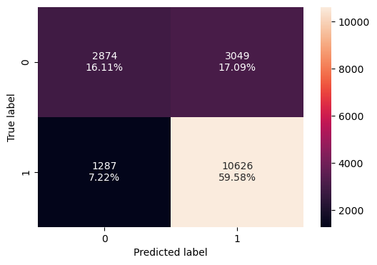

```python
confusion_matrix_sklearn(xgb_tuned, X_train,y_train)
```

```python
xgb_tuned_model_train_perf=model_performance_classification_sklearn(xgb_tuned, X_train,y_train)
print("Training performance \n",xgb_tuned_model_train_perf)
```

```
Training performance
    Accuracy  Recall  Precision    F1
0     0.757   0.892      0.777 0.831
```

##### Revisión del rendimiento en el conjunto de prueba

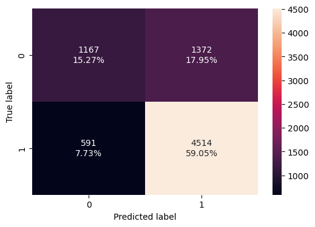

```python
confusion_matrix_sklearn(xgb_tuned, X_test,y_test)
```

```python
xgb_tuned_model_test_perf=model_performance_classification_sklearn(xgb_tuned, X_test, y_test)
print("Testing performance \n",xgb_tuned_model_test_perf)
```

```
Testing performance
    Accuracy  Recall  Precision    F1
0     0.743   0.884      0.767 0.821
```

###### Observaciones Clasificador XGBoost ajustado

- El modelo XG BOOST Ajustado generaliza bien los datos de entrenamiento y prueba.
- Como los demás modelos, este modelo sigue siendo más fuerte en Recall (0.88)
- Este modelo utilizando ajuste, es mejor que el no ajustado, ya que el no XG_Boost no ajustado tendía a sobreajustar.
- El f1_score, métrica de importancia es de 0.82, que se puede considerar aceptable.
- Sería recomendable, seguir ajustando los hiperámetros se pueda mejorar el f1_score para equilibrar más el modelo:
- Talvez disminuir learning_rate para controla la contribución de cada árbol en el ensamblaje.Un valor más bajo talvez permita mejorar la generalización y aumentar n_estimators.

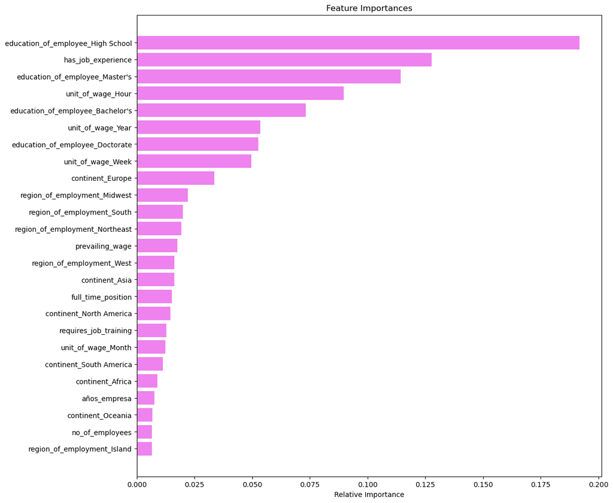

```python
#Visualización de las carácteristicas importantes de XG BOOST
importances = xgb_tuned.feature_importances_
indices = np.argsort(importances)
feature_names = list(X.columns)

plt.figure(figsize=(12,12))
plt.title('Feature Importances')
plt.barh(range(len(indices)), importances[indices], color='violet', align='center')
plt.yticks(range(len(indices)), [feature_names[i] for i in indices])
plt.xlabel('Relative Importance')
plt.show()
```

## Modelo Stacking

Un modelo de apilamiento ó Stacking es una técnica de aprendizaje automático que combina las predicciones de varios modelos individuales, llamados "modelos base" o "modelos de nivel inferior", para mejorar la precisión general de la predicción. En lugar de depender de un solo modelo, el modelo de apilamiento utiliza la información de múltiples modelos para tomar una decisión final.

**Se construirá un modelo Stacking con los modelos ajustados: árbol de decisión, bosque aleatorio, adaboost, aumento de gradiente, luego usemos XGBoost para obtener la predicción final.**

```python
#Modelos a incorporar a Stacking
estimators=[ ("Decision Tree", dtree_estimator),
               ("Random Forest", rf_estimator),
               ("AdaBoost", abc_tuned),
               ("Gradient Boosting", gbc_tuned),
               ("XGBoost ", xgb_tuned) ]

final_estimator = XGBClassifier(random_state=1)
```

```python
stacking_classifier =StackingClassifier(estimators=estimators, final_estimator=final_estimator,cv=5)
stacking_classifier.fit(X_train,y_train)
```

```
StackingClassifier(cv=5,
                   estimators=[('Decision Tree',
                                DecisionTreeClassifier(class_weight={0: 0.67,
                                                                     1: 0.33},
                                                       max_depth=1,
                                                       max_leaf_nodes=2,
                                                       min_impurity_decrease=0.0001,
                                                       min_samples_leaf=5,
                                                       random_state=1)),
                               ('Random Forest',
                                RandomForestClassifier(max_depth=5,
                                                       max_features=0.7,
                                                       min_samples_leaf=19,
                                                       n_estimators=500,
                                                       random_state=1)),
                               ('AdaBoost',
                                AdaBoostClassifier...
                                                 feature_types=None, gamma=None,
                                                 grow_policy=None,
                                                 importance_type=None,
                                                 interaction_constraints=None,
                                                 learning_rate=None,
                                                 max_bin=None,
                                                 max_cat_threshold=None,
                                                 max_cat_to_onehot=None,
                                                 max_delta_step=None,
                                                 max_depth=None,
                                                 max_leaves=None,
                                                 min_child_weight=None,
                                                 missing=nan,
                                                 monotone_constraints=None,
                                                 multi_strategy=None,
                                                 n_estimators=None, n_jobs=None,
                                                 num_parallel_tree=None,
                                                 random_state=1, ...))
```

##### Revisión del rendimiento en el conjunto de entrenamiento

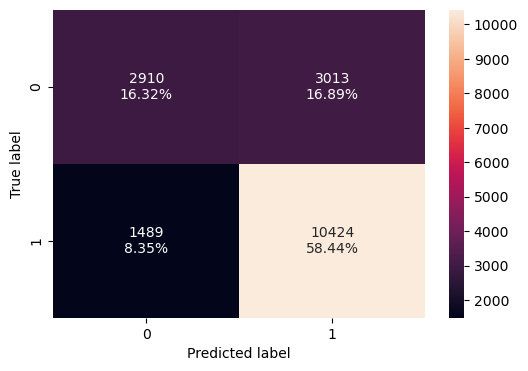

```python
confusion_matrix_sklearn(stacking_classifier, X_train,y_train)
```

```python
stacking_classifier_model_train_perf=model_performance_classification_sklearn(stacking_classifier, X_train,y_train)
print("Training performance \n",stacking_classifier_model_train_perf)
```

```
Training performance
    Accuracy  Recall  Precision    F1
0     0.748   0.875      0.776 0.822
```

##### Revisión del rendimiento en el conjunto de prueba

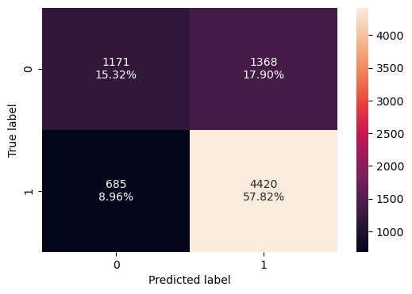

```python
confusion_matrix_sklearn(stacking_classifier, X_test,y_test)
```

```python
stacking_classifier_model_test_perf=model_performance_classification_sklearn(stacking_classifier, X_test, y_test)
print("Testing performance \n",stacking_classifier_model_test_perf)
```

```
Testing performance
    Accuracy  Recall  Precision    F1
0     0.731   0.866      0.764 0.812
```

##### Observaciones Modelo Stacking:

```python
# Stacking_classifier
stacking_classifier.fit(X_train, y_train)

# Acceder a los modelos base dentro del StackingClassifier
base_models = stacking_classifier.named_estimators_.values()

# Calcular la importancia de características para cada modelo base
for model in base_models:
    if hasattr(model, "feature_importances_"):
        feature_importance = model.feature_importances_
        print(pd.DataFrame(feature_importance, columns=["Imp"], index=X_train.columns).sort_values(by='Imp', ascending=False))
```

```
                                    Imp
education_of_employee_High School 1.000
has_job_experience                0.000
education_of_employee_Doctorate   0.000
unit_of_wage_Week                 0.000
unit_of_wage_Month                0.000
unit_of_wage_Hour                 0.000
region_of_employment_West         0.000
region_of_employment_South        0.000
region_of_employment_Northeast    0.000
region_of_employment_Midwest      0.000
region_of_employment_Island       0.000
education_of_employee_Master's    0.000
education_of_employee_Bachelor's  0.000
requires_job_training             0.000
continent_South America           0.000
continent_Oceania                 0.000
continent_North America           0.000
continent_Europe                  0.000
continent_Asia                    0.000
continent_Africa                  0.000
años_empresa                      0.000
full_time_position                0.000
prevailing_wage                   0.000
no_of_employees                   0.000
unit_of_wage_Year                 0.000
                                    Imp
education_of_employee_High School 0.351
has_job_experience                0.168
unit_of_wage_Hour                 0.111
education_of_employee_Bachelor's  0.096
prevailing_wage                   0.069
continent_Europe                  0.054
education_of_employee_Master's    0.044
education_of_employee_Doctorate   0.020
region_of_employment_Midwest      0.018
continent_Asia                    0.013
unit_of_wage_Year                 0.012
continent_North America           0.010
region_of_employment_West         0.009
```

[output cut: 75 more lines]

```
region_of_employment_South        0.020
region_of_employment_Northeast    0.019
prevailing_wage                   0.017
region_of_employment_West         0.016
continent_Asia                    0.016
full_time_position                0.015
continent_North America           0.015
requires_job_training             0.013
unit_of_wage_Month                0.012
continent_South America           0.011
continent_Africa                  0.009
años_empresa                      0.008
continent_Oceania                 0.007
no_of_employees                   0.007
region_of_employment_Island       0.007
```

### Comparación de rendimiento de los modelos -BOOSTING-

```python
##  Función para calcular métricas de rendimiento del modelo
def get_metrics_score(model,flag=True):
    '''
    model : classifier to predict values of X

    '''
    # defining an empty list to store train and test results
    score_list=[]

    pred_train = model.predict(X_train)
    pred_test = model.predict(X_test)

    train_acc = model.score(X_train,y_train)
    test_acc = model.score(X_test,y_test)

    train_recall = metrics.recall_score(y_train,pred_train)
    test_recall = metrics.recall_score(y_test,pred_test)

    train_precision = metrics.precision_score(y_train,pred_train)
    test_precision = metrics.precision_score(y_test,pred_test)

    train_f1_score = metrics.f1_score(y_train,pred_train)
    test_f1_score = metrics.f1_score(y_test,pred_test)

    score_list.extend((train_acc,test_acc,train_recall,test_recall,train_precision,test_precision, train_f1_score,test_f1_score))

    # If the flag is set to True then only the following print statements will be dispayed. The default value is set to True.
    if flag == True:
        print("Accuracy on training set : ",model.score(X_train,y_train))
        print("Accuracy on test set : ",model.score(X_test,y_test))
        print("Recall on training set : ",metrics.recall_score(y_train,pred_train))
        print("Recall on test set : ",metrics.recall_score(y_test,pred_test))
        print("Precision on training set : ",metrics.precision_score(y_train,pred_train))
        print("Precision on test set : ",metrics.precision_score(y_test,pred_test))
        print("f1_score on training set : ",metrics.f1_score(y_train,pred_train))
        print("f1_score on test set : ",metrics.f1_score(y_test,pred_test))

    return score_list # returning the list with train and test scores
```

```python
# Lista de los modelos ejecutados
models = [abclassifier, abc_tuned, gbc, gbc_init, gbc_tuned, xgb, xgb_tuned,stacking_classifier]

# Definir listas vacias para añadir a los resultados de entrenamiento y prueba
acc_train = []
acc_test = []
recall_train = []
recall_test = []
precision_train = []
precision_test = []
f1_score_train = []
f1_score_test = []

# Bucle para predecir las métricas de rendimiento
for model in models:
    j = get_metrics_score(model,False)
    acc_train.append(np.round(j[0],2))
    acc_test.append(np.round(j[1],2))
    recall_train.append(np.round(j[2],2))
    recall_test.append(np.round(j[3],2))
    precision_train.append(np.round(j[4],2))
    precision_test.append(np.round(j[5],2))
    f1_score_train.append(np.round(j[6],2))
    f1_score_test.append(np.round(j[7],2))
```

```python
comparison_frame = pd.DataFrame({'Model':['AdaBoost with default paramters','AdaBoost Tuned',
                                          'Gradient Boosting with default parameters','Gradient Boosting with init=AdaBoost',
                                          'Gradient Boosting Tuned','XGBoost with default parameters','XGBoost Tuned',"Stacking_classifier"],
                                          'Train_Accuracy': acc_train,'Test_Accuracy': acc_test,
                                          'Train_Recall':recall_train,'Test_Recall':recall_test,
                                          'Train_Precision':precision_train,'Test_Precision':precision_test,
                                          'Train_f1_score':f1_score_train,'Test_f1_score':f1_score_test
                                })
comparison_frame
```

|  | Model | Train_Accuracy | Test_Accuracy | Train_Recall | Test_Recall | Train_Precision | Test_Precision | Train_f1_score | Test_f1_score |
| --- | --- | --- | --- | --- | --- | --- | --- | --- | --- |
| 0 | AdaBoost with default paramters | 0.740 | 0.730 | 0.890 | 0.880 | 0.760 | 0.760 | 0.820 | 0.820 |
| 1 | AdaBoost Tuned | 0.750 | 0.740 | 0.890 | 0.880 | 0.780 | 0.770 | 0.830 | 0.820 |
| 2 | Gradient Boosting with default parameters | 0.760 | 0.750 | 0.880 | 0.880 | 0.780 | 0.770 | 0.830 | 0.820 |
| 3 | Gradient Boosting with init=AdaBoost | 0.760 | 0.750 | 0.880 | 0.880 | 0.780 | 0.770 | 0.830 | 0.820 |
| 4 | Gradient Boosting Tuned | 0.760 | 0.750 | 0.880 | 0.880 | 0.780 | 0.770 | 0.830 | 0.820 |
| 5 | XGBoost with default parameters | 0.840 | 0.730 | 0.930 | 0.850 | 0.850 | 0.770 | 0.890 | 0.810 |
| 6 | XGBoost Tuned | 0.760 | 0.740 | 0.890 | 0.880 | 0.780 | 0.770 | 0.830 | 0.820 |
| 7 | Stacking_classifier | 0.750 | 0.730 | 0.880 | 0.870 | 0.780 | 0.760 | 0.820 | 0.810 |

## Conclusiones

#### Comparación de rendimiento del modelo

#### ¿Mejorará el rendimiento del modelo el ajuste de los hiperparámetros?

Según los resultados obtenidos, en este caso particular parece que ajustar los hiperparámetros no ha tenido un impacto tan significativo en el rendimiento del modelo en términos de F1-score, que es la métrica de mayor interés en este caso.

Comparando modelos:

**AdaBoost:** El modelo AdaBoost con hiperparámetros ajustados (AdaBoost Tuned) no muestra una mejora en el F1-score en comparación con el modelo AdaBoost con parámetros predeterminados. Para ambos modelos, no se tiene sobreajuste.

**Gradient Boosting:** Tanto el modelo Gradient Boosting con parámetros predeterminados como el modelo Gradient Boosting con hiperparámetros ajustados tienen resultados prácticamente idénticos en términos de F1-score. No se observa una mejora sustancial al ajustar los hiperparámetros.

Esto sugiere que, en este caso, los hiperparámetros predeterminados no funcionan mejor para XGBoost en términos de F1-score. Sin embargo este modelo XGBoost with default parameter, podría estar sobreajustado debido a que el rendimiento de F1 de entrenamiento es 0.89, no así en el de prueba (0.81)

**Stacking:**

El modelo Stacking_classifier muestra un F1-score similar al de AdaBoost con hiperparámetros ajustados , Gradient Boosting con hiperparámetros ajustados.

No parece haber una mejora significativa en el rendimiento con respecto a las métricas de F1-score. En general, basándonos en la métrica F1-score y los resultados obtenidos, no parece que el ajuste de hiperparámetros haya llevado a una mejora sustancial en el rendimiento de los modelos.

Es importante destacar que el rendimiento de los modelos puede depender en gran medida de los datos específicos y las características del problema. Por lo tanto, es recomendable seguir explorando otras estrategias, como la ingeniería de características o la selección de características, para mejorar aún más el rendimiento de los modelos.

Además, es **importante considerar la eficiencia computacional** y el tiempo de entrenamiento al seleccionar modelos y ajustar hiperparámetros, ya que algunos modelos pueden requerir más recursos computacionales que otros.

En general, además de observar el F1-score como la métrica de mayor interés, también es importante considerar otras métricas para evaluar el rendimiento de los modelos de clasificación, ya que brindan información adicional sobre diferentes aspectos del modelo. Aquí hay algunas observaciones sobre las otras métricas que se presentaron en los resultados:

**Accuracy (Precisión):**

**Recall (Sensibilidad):**

El recall mide la proporción de casos positivos reales que se predicen correctamente como positivos. En general, los modelos muestran un recall alto, que oscila entre el 85% y el 93%. Esto sugiere que los modelos son efectivos para identificar casos de visa aprobada (clase 1).

**Precision (Precisión):**

##### Comparación de rendimiento del modelo y conclusiones

## Información práctica y recomendaciones

- Se recomienda proseguir la optimización de hiperparámetros del modelo que maximice el F1-score. Esto puede incluir ajustar la profundidad del árbol (en el caso de árboles de decisión), el número de estimadores (en el caso de métodos de ensamble como AdaBoost o Gradient Boosting), la tasa de aprendizaje, por ejemplo, para esto se requiere de más tiempo y poder computacional.
- Aunque el f1_score obtenido no es malo ( 0.80 a 0.82), está influenciado por el umbral de decisión utilizado para convertir las probabilidades pronosticadas en etiquetas de clase. El umbral de decisión se utiliza para equilibrar la precisión y el recall de manera que maximice el F1-score. Ya que a pesar que modelos como XG_bOOST_ajustado generaliza bien, siguen siendo más altos en recall (0.88), y cuando la precisión es baja en un modelo de clasificación (0.77 menor a Recall), indica que el modelo está cometiendo más falsos positivos en comparación con los verdaderos positivos. En otras palabras, el modelo está etiquetando incorrectamente algunas instancias negativas como positivas.
- En el contexto de nuestro modelo de predicción de visas, a menor precisión significaría que el modelo está otorgando visas a personas que en realidad no deberían calificar para ellas, lo que puede ser costoso o problemático desde una perspectiva legal o de política. Por lo tanto, si el objetivo es maximizar la precisión en busca de un mayor equilibro con recall, se debe prestar atención a reducir los falsos positivos, lo que podría lograrse como ya se mencionó mediante ajustes en el umbral de decisión, la selección de características, el equilibrio de clases o la optimización del modelo en general.

De las caracteristicas importante que destaca el modelo XG_bOOST_ajustado y otros clasificadores de boosting, para nuestro modelo de predicción, se rescantan estas caracteristicas:

**La educación del empleado_ High School** es la característica más importante según todos los modelos, como tuned AdaBoost y gradiente poteniado ajustado. Sin embargo existen exepciones.

Al igual que en los modelos de bagging, esto puede indicar que usualmente las solicitudes de visa relacionadas a un nivel de estudo High School son denegadas.

**La experiencia laboral** es otro factor importante para conseguir una aprobación.

**La educación del empleado_ Master:** Suelen tener una aprobación mayor de visas,así como salarios prevalecientes altos.

**Continente** la solicitud provenga de Europa, la mayoría de los casos son visas certificadas.

**Salario prevaleciente:** A mayor salario prevaleciente, según la zona y el nivel de estudios, hay opciones de certificar la visa.

## Apéndice: Análisis detallado de datos exploratorios(EDA)

### ANALISIS EXPLORATORIO DE DATOS

ANALISIS UNIVARIADO

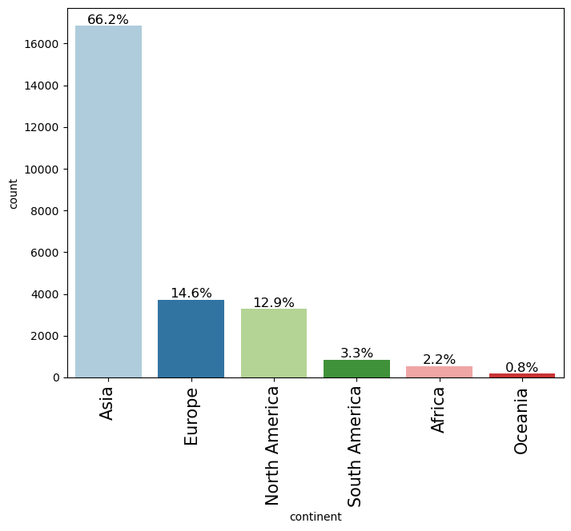

```python
labeled_barplot(data, "continent", perc=True)
```

- En este orden: Asia, Europa, Norte América, Sur America, Africa y Oceania, es porcentaje de mayor a menor de las solicitudes por continente.
- Asia domina el 66 % de las solicitudes.

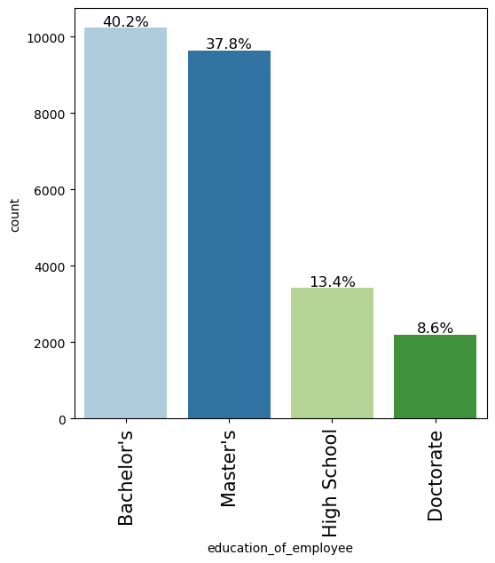

```python
labeled_barplot(data, "education_of_employee", perc=True)
```

- Los aplicantes con nivel educativo de Bachillerato, lideran las solicitudes, con un 40%, seguidos de Masters 37.8% , High_School 13.4%, en menor instancia Doctorados (8.6%)

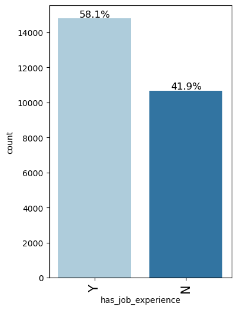

```python
labeled_barplot(data, "has_job_experience", perc=True)
```

- Un 58.1% de las aplicaciones, tienen experiencia de trabajo, el resto no.

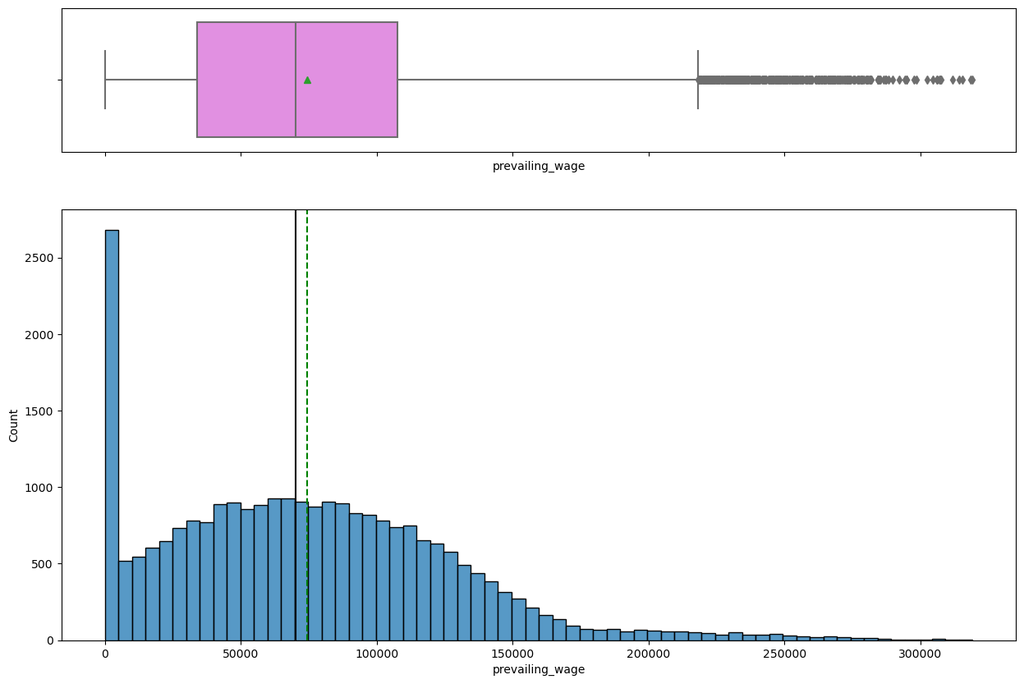

```python
#Observaciones "prevailing_wage"
histogram_boxplot(data,'prevailing_wage')
```

```python
data["prevailing_wage"].describe()
```

```
count    25480.000
mean     74455.815
std      52815.942
min          2.137
25%      34015.480
50%      70308.210
75%     107735.513
max     319210.270
Name: prevailing_wage, dtype: float64
```

- Para salario prevaleciente, los datos tienen sesgo hacia la derecha.
- El salario promedio es un poco mayor a 74 000 y la mediana esta cerca, en 70000 aproximadamente
- El salario promedio depende de varios factores.

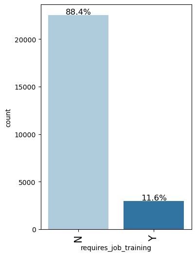

```python
#Observaciones "requires_job_training"
labeled_barplot(data, "requires_job_training", perc=True)
```

- La mayoría de los aplicantes a visa, no requieren capacitación.

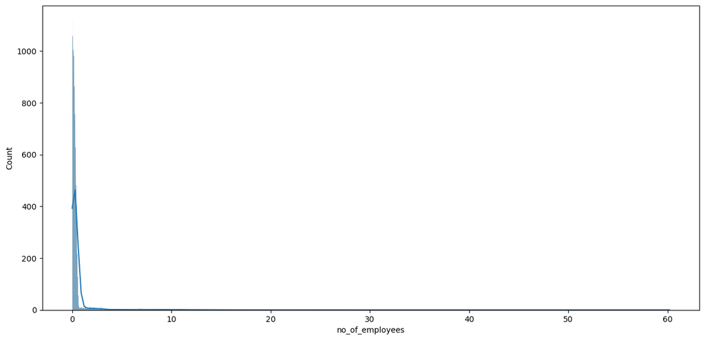

```python
# Histograma de no_de_empleados
plt.figure(figsize=(15, 7))
sns.histplot(data=data, x=data["no_of_employees"]/10000, kde= True)
```

```python
# Revisión de no_of_employees
data["no_of_employees"].describe()
```

```
count    25480.000
mean      5667.043
std      22877.929
min        -26.000
25%       1022.000
50%       2109.000
75%       3504.000
max     602069.000
Name: no_of_employees, dtype: float64
```

```python
# Filtra los casos en los que "no_of_employees" sea menor o igual a 0
filtered_data = data[data["no_of_employees"] <= 0]

# Muestra información sobre los casos resultantes, incluyendo "case_status"
print(filtered_data["case_status"].value_counts())
```

```
Certified    17
Denied       16
Name: case_status, dtype: int64
```

```python
filtered_data.head()
```

|  | case_id | continent | education_of_employee | has_job_experience | requires_job_training | no_of_employees | yr_of_estab | region_of_employment | prevailing_wage | unit_of_wage | full_time_position | case_status | años_empresa |
| --- | --- | --- | --- | --- | --- | --- | --- | --- | --- | --- | --- | --- | --- |
| 245 | EZYV246 | Europe | Master's | N | N | -25 | 1980 | Northeast | 39452.990 | Year | Y | Certified | 36 |
| 378 | EZYV379 | Asia | Bachelor's | N | Y | -11 | 2011 | Northeast | 32506.140 | Year | Y | Denied | 5 |
| 832 | EZYV833 | South America | Master's | Y | N | -17 | 2002 | South | 129701.940 | Year | Y | Certified | 14 |
| 2918 | EZYV2919 | Asia | Master's | Y | N | -26 | 2005 | Midwest | 112799.460 | Year | Y | Certified | 11 |
| 6439 | EZYV6440 | Asia | Bachelor's | N | N | -14 | 2013 | South | 103.970 | Hour | Y | Denied | 3 |

- Efectivamente parece haber un error con esta columna, posiblemente devieron ser números positivos.

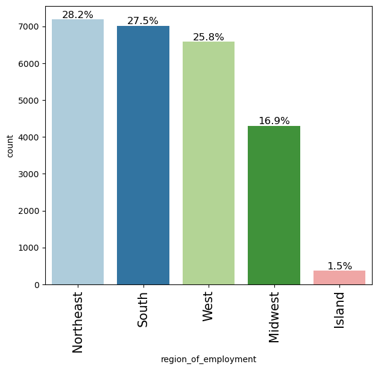

```python
#Observaciones "region_of_employment"
labeled_barplot(data, "region_of_employment", perc=True)
```

- Las regiones North East, South, West son las más demandadas en solicitudes para trabajo, de 28% a 26% respectivamente
- Midwest es una region con el 16.9% de las solicitudes
- La regioón con menor cantidad de oferta laboral es Island.

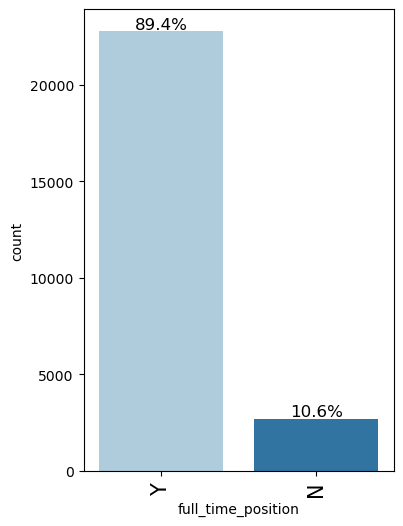

```python
#Observaciones "full_time_position"
labeled_barplot(data, "full_time_position", perc=True)
```

- La mayoria de las aplicaciones a trabajo, son de tiempo completo

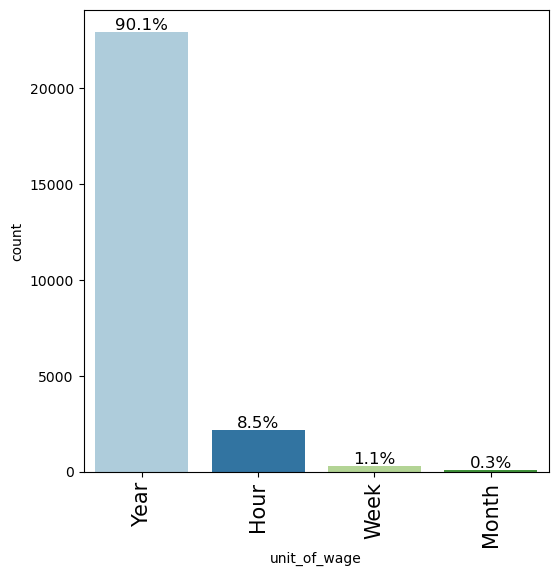

```python
#Observaciones "unit_of_wage"
labeled_barplot(data, "unit_of_wage", perc=True)
```

- La mayor cantidad de solicitudes (90%) son de Unidad de salario prevaleciente anual, seguido de por horas.

ANALISIS MULTIVARIADO

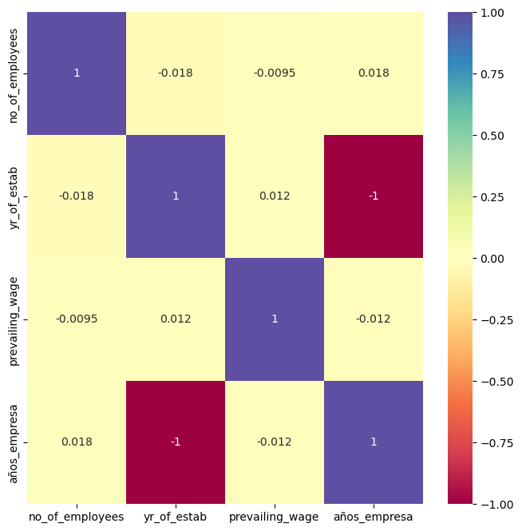

```python
plt.figure(figsize=(8,8))
sns.heatmap(data.corr(),annot=True,cmap='Spectral',vmin=-1,vmax=1)
plt.show();
```

- No se tiene una relación directa con variables numéricas.

```python
# Filtra los casos en los que unit_of_wage =="Year"
unit_of_wage_filtered_data = data[data["unit_of_wage"]=="Year"]

# Muestra información sobre los casos resultantes, incluyendo "case_status"
print(unit_of_wage_filtered_data["prevailing_wage"].mean())
```

```
81228.07713308945
```

- El salario prevaleciente promedio para un contrato anual es 81228.

```python
# Filtra los casos en los que "case_status"=="Certified"
estado_visac = data[data["case_status"]=="Certified" ]

# Filtra los casos en los que "case_status"=="Denied"
estado_visaN = data[data["case_status"]=="Denied" ]
```

```python
# Muestra información sobre los casos resultantes, i
print(estado_visac["prevailing_wage"].mean())

print(estado_visac["full_time_position"].value_counts(normalize=True))
print(estado_visac["region_of_employment"].value_counts(normalize=True))
print(estado_visac["has_job_experience"].value_counts(normalize=True))
print(estado_visac["continent"].value_counts(normalize=True))
```

```
77293.6192431308
Y   0.891
N   0.109
Name: full_time_position, dtype: float64
South       0.289
Northeast   0.266
West        0.241
Midwest     0.191
Island      0.013
Name: region_of_employment, dtype: float64
Y   0.648
N   0.352
Name: has_job_experience, dtype: float64
Asia            0.647
Europe          0.174
North America   0.120
South America   0.029
Africa          0.023
Oceania         0.007
Name: continent, dtype: float64
```

- El salario prevaleciente promedio para una visa aprobada es de 77293.
- La región con más popularidad en las visas aprobadas es la Sur (28%), seguida de Norteast (26%)
- Los continentes con mayor visas aprobadas son Asia, y Europa.

```python
#Sector con nivel de estudio High_school y visa denegada

ESTUDIOSN = estado_visaN[estado_visaN["education_of_employee"] == "High School"]
ESTUDIOSA = estado_visac[estado_visac["education_of_employee"] == "High School"]

print("Visas denegadas High School")
print(ESTUDIOS["has_job_experience"].value_counts(normalize=True))
```

[output not shown]

```python
print ("Visas aprobadas High School")
print(ESTUDIOSA["has_job_experience"].value_counts(normalize=True))
```

```
Visas aprobadas High School
Y   0.620
N   0.380
Name: has_job_experience, dtype: float64
```

```
continent    Africa  Asia  Europe  North America  Oceania  South America   All
case_status
Certified        23   676     162            210       19             74  1164
All              23   676     162            210       19             74  1164
------------------------------------------------------------------------------------------------------------------------
```

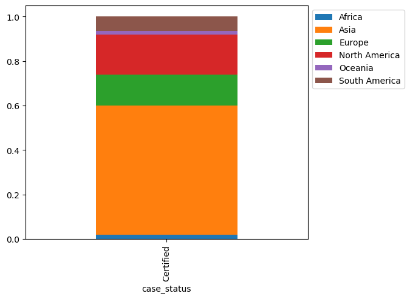

```python
#Visas aprobadas, con condición de estudio High_school
stacked_barplot(ESTUDIOSA,"case_status","continent")
```

```python
#Visas aprobadas sumario
estado_visac.describe()
```

|  | no_of_employees | yr_of_estab | prevailing_wage | años_empresa |
| --- | --- | --- | --- | --- |
| count | 17018.000 | 17018.000 | 17018.000 | 17018.000 |
| mean | 5807.018 | 1979.667 | 77293.619 | 36.333 |
| std | 23119.575 | 42.279 | 52042.716 | 42.279 |
| min | -26.000 | 1800.000 | 2.137 | 0.000 |
| 25% | 1035.250 | 1976.000 | 38375.330 | 11.000 |
| 50% | 2147.000 | 1997.000 | 72486.270 | 19.000 |
| 75% | 3575.000 | 2005.000 | 108879.107 | 40.000 |
| max | 602069.000 | 2016.000 | 318446.050 | 216.000 |

```python
#Visas aprobadas sumario
estado_visac.describe(include=['category']).T
```

|  | count | unique | top | freq |
| --- | --- | --- | --- | --- |
| case_id | 17018 | 17018 | EZYV21458 | 1 |
| continent | 17018 | 6 | Asia | 11012 |
| education_of_employee | 17018 | 4 | Master's | 7575 |
| has_job_experience | 17018 | 2 | Y | 11024 |
| requires_job_training | 17018 | 2 | N | 15012 |
| region_of_employment | 17018 | 5 | South | 4913 |
| unit_of_wage | 17018 | 4 | Year | 16047 |
| full_time_position | 17018 | 2 | Y | 15163 |
| case_status | 17018 | 1 | Certified | 17018 |

Para visas con estado certificado, los valores asociados de mayor frecuencia son: -Continente: asia -Educación_of_employee: Masters -Tiene experiencia laboral: Si - Requiere capacitación para laborar: No - Unidad de pago: Year - Trabajo de tiempo completo: Si - Región donde va a trabajar: South - Salario promedio prevaleciente: 77293 No necesariamente en esta combinación, sino que estas son las características individuales con mayor peso

```python
#Para el caso de visas denegadas, es común
estado_visaN.describe()
```

|  | no_of_employees | yr_of_estab | prevailing_wage | años_empresa |
| --- | --- | --- | --- | --- |
| count | 8462.000 | 8462.000 | 8462.000 | 8462.000 |
| mean | 5385.538 | 1978.893 | 68748.682 | 37.107 |
| std | 22382.756 | 42.542 | 53890.166 | 42.542 |
| min | -26.000 | 1800.000 | 2.956 | 0.000 |
| 25% | 991.000 | 1975.000 | 23497.295 | 12.000 |
| 50% | 2032.500 | 1997.000 | 65431.460 | 19.000 |
| 75% | 3386.750 | 2004.000 | 105097.640 | 41.000 |
| max | 594472.000 | 2016.000 | 319210.270 | 216.000 |

```python
#Para el caso de visas denegadas, es común
estado_visaN.describe(include=['category']).T
```

|  | count | unique | top | freq |
| --- | --- | --- | --- | --- |
| case_id | 8462 | 8462 | EZYV01 | 1 |
| continent | 8462 | 6 | Asia | 5849 |
| education_of_employee | 8462 | 4 | Bachelor's | 3867 |
| has_job_experience | 8462 | 2 | N | 4684 |
| requires_job_training | 8462 | 2 | N | 7513 |
| region_of_employment | 8462 | 5 | Northeast | 2669 |
| unit_of_wage | 8462 | 4 | Year | 6915 |
| full_time_position | 8462 | 2 | Y | 7610 |
| case_status | 8462 | 1 | Denied | 8462 |

```python
duf = pd.DataFrame(data)

# Filtrar las filas donde la misma combinación de características se repite más de una vez
#duplicated_rows = duf[duf.duplicated(subset=['case_status', 'continent',"education_of_employee","has_job_experience","full_time_position" ], keep=False)]

#Ordenarlas por frecuencia en combinación de características
frequency = duf.groupby(['case_status', 'continent',"education_of_employee","has_job_experience","full_time_position","region_of_employment","requires_job_training", "unit_of_wage" ]).size().reset_index(name='Frequency')
#print(frequency)
```

```python
#Se ordenan de mayor a menor frecuencia
frequency_sorted = frequency.sort_values(by='Frequency', ascending=False)
#print(frequency_sorted)
```

- Combinaciones de mayor fecuencia Case_estatus= Certificado y Denegado

```python
#Se escoge la frecuencia a revisar que cumple el patrón de combinación
most_frequent_combination = frequency_sorted.iloc[0]

print(most_frequent_combination)
```

```
case_status              Certified
continent                     Asia
education_of_employee     Master's
has_job_experience               Y
full_time_position               Y
region_of_employment       Midwest
requires_job_training            N
unit_of_wage                  Year
Frequency                      700
Name: 1251, dtype: object
```

```python
#Se escoge la segunda con mayor  frecuencia a revisar que cumple el patron de combinación
most_frequent_combination = frequency_sorted.iloc[1]

print(most_frequent_combination)
```

```
case_status              Certified
continent                     Asia
education_of_employee     Master's
has_job_experience               Y
full_time_position               Y
region_of_employment         South
requires_job_training            N
unit_of_wage                  Year
Frequency                      685
Name: 1267, dtype: object
```

```python
most_frequent_combination = frequency_sorted.iloc[2]

print(most_frequent_combination)
```

```
case_status              Certified
continent                     Asia
education_of_employee     Master's
has_job_experience               Y
full_time_position               Y
region_of_employment     Northeast
requires_job_training            N
unit_of_wage                  Year
Frequency                      676
Name: 1259, dtype: object
```

```python
most_frequent_combination = frequency_sorted.iloc[9]

print(most_frequent_combination)
```

```
case_status                  Denied
continent                      Asia
education_of_employee    Bachelor's
has_job_experience                N
full_time_position                Y
region_of_employment           West
requires_job_training             N
unit_of_wage                   Year
Frequency                       317
Name: 4555, dtype: object
```

- Por ejemplo, para una persona que proviene de Asia, tiene más probabilidades de certificar su visa si cumple los siguientes requisitos:

continent Asia  
education_of_employee Master's  
has_job_experience Y  
full_time_position Y  
region_of_employment Midwest  
requires_job_training N  
unit_of_wage Year

- Ahora, puede perder su visa, si mantiene constante el resto de carácteristicas, pero pasa a una región de trabajo como West, además tiene un nivel universitario de Bachiller y no tiene experiencia:

continent Asia  
education_of_employee Bachelor's  
has_job_experience N  
full_time_position Y  
region_of_employment West  
requires_job_training N  
unit_of_wage Year

```python
# Nueva columna para facilidad de interpretar los datos "años_empresa"
data["años_empresa"]= 2016-data["yr_of_estab"]
data["años_empresa"].value_counts()
```

```
18     1134
11     1051
15     1017
9       994
17      870
       ...
174       6
170       4
194       4
206       3
192       2
Name: años_empresa, Length: 199, dtype: int64
```

- Efectivamente "años_empresa" es una variable con mucha variabilidad.

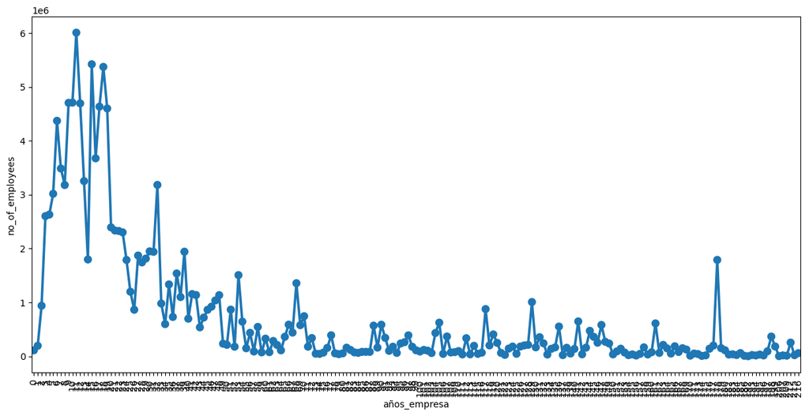

```python
# Numero de empleados, respecto el tiempo de la empresa
plt.figure(figsize=(15, 7))
sns.pointplot(x='años_empresa', y='no_of_employees', data=data, estimator=sum, ci=None)
plt.xticks(rotation=90);
```

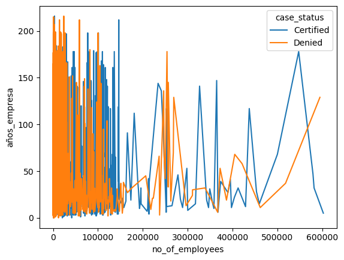

```python
# Numero de empleados, respecto el tiempo de la empresa- por estatus de visa
sns.lineplot(data=data,x = 'no_of_employees' , y = 'años_empresa', ci = False ,hue='case_status');
```

- Parece que hay una tendencia que a mayor tiempo de consolidada la empresa, menos empleados.
- No se nota un patrón de visas aceptadas asociadas a número de empleados y tiempo de la empresa.

[output not shown]

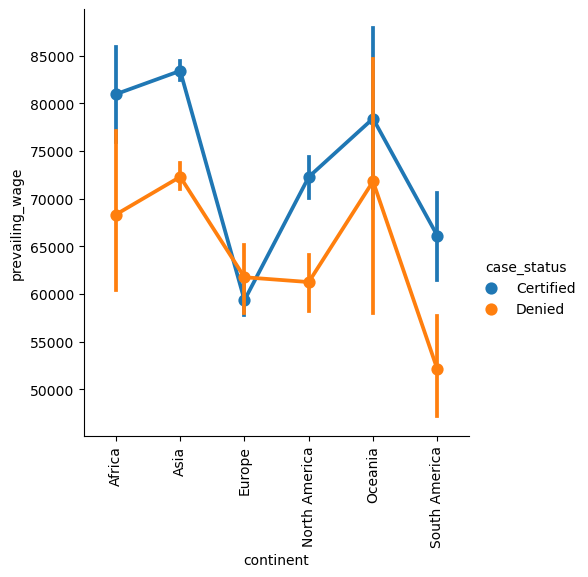

```python
#Observaciones entre salario prevaleciente y continente
plt.figure(figsize=(25,15))
sns.catplot(data=data, x='continent', y='prevailing_wage', hue='case_status', kind='point');
plt.xticks(rotation=90)
```

- El patron incida que en todos los continentes, menos el Europeo, hay más posibilidad de que se le apruebe la visa mientras mayor sea la prevailing_wage promedio asociada a esa solicitud.
- En el caso de Europa, parece que esto no es un factor que se considera para aprobar o reprobar una visa. Acorde a estos datos, para todos los continentes, a excepción del Europeo, hay más posibilidad de que se le apruebe la visa mientras mayor sea la tasa de salario prevaleciente a la que el candidato puede aspirar.

```
(array([0, 1]), [Text(0, 0, 'N'), Text(1, 0, 'Y')])
```

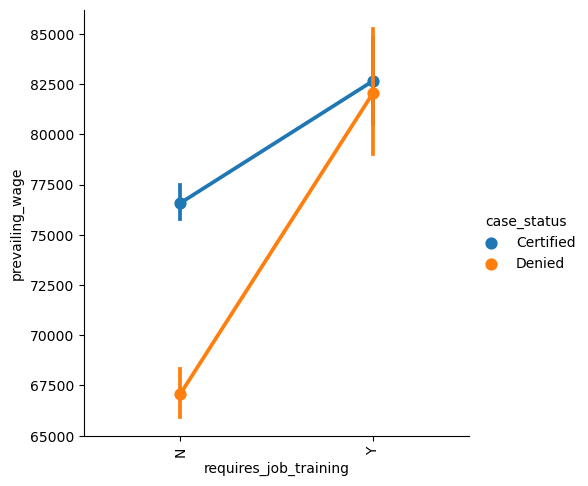

```python
#Observaciones entre salario prevaleciente y si el trabajador requiere capacitación
plt.figure(figsize=(25,15))
sns.catplot(data=data, x='requires_job_training', y='prevailing_wage', hue='case_status', kind='point');
plt.xticks(rotation=90)
```

- El salario prevaleciente promedio también parece ser un factor importante, más que si se requiera ó no capacitación, por ejemplo,para los casos con salarios prevalecientes menores a 75000, la tendencia es que el estatus migratorio sea denegado, incluso si el candidato no requiere de ninguna capacitación.
- Esto podría indicar, que el gobierno tendrá mayor voluntad de aprobar visas, a mayor posibilidad tenga el aspirante de sostenerse o generar mayor beneficio económico.
- En el caso de los datos con salarios superiores a 75 000, y en general, los casos con visa denegada, se presenta mayor variabilidad entre los datos.
- Es importante revisar, que factores pueden afectar la obtención de la visa, en el caso de los aspirantes con salarios prevalecientes mayores a 75000 pero que les denegó.
- Hay un patron que indica que una tendencia creciente en el salario prevaleciente y que el empleado requiera capacitación laboral (YES).

```
(array([0, 1]), [Text(0, 0, 'N'), Text(1, 0, 'Y')])
```

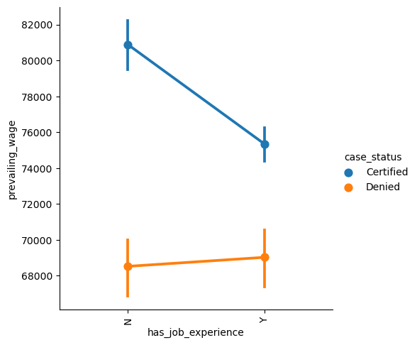

```python
#Observaciones entre salario prevaleciente y si el trabajador requiere capacitación
plt.figure(figsize=(25,15))
sns.catplot(data=data, x='has_job_experience', y='prevailing_wage', hue='case_status', kind='point');
plt.xticks(rotation=90)
```

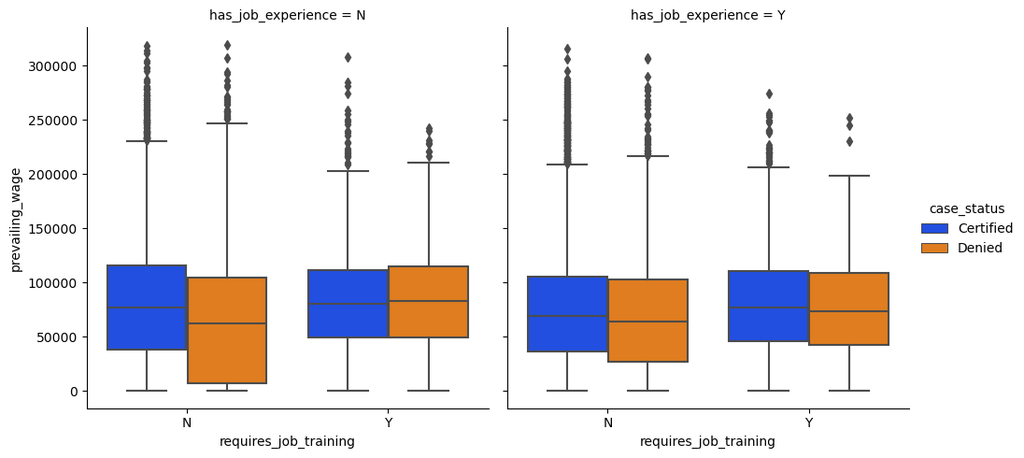

```python
sns.catplot(data=data, x='requires_job_training', y='prevailing_wage', hue='case_status', col="has_job_experience", kind='box', palette='bright');
```

- Respecto a la experiencia de trabajo del solicitante, los casos en donde los salarios prevalecientes promedio son mayores a 74 000 no importa si tiene o no tiene el solicitante experiencia laboral, la tendencia es aprobar la visa mientras se supere el salario prevaleciente asociado del solicitante.

[output not shown]

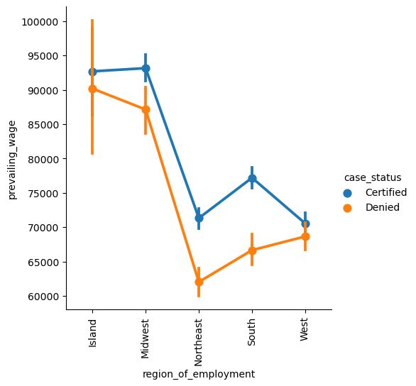

```python
#Observaciones entre salario prevaleciente y la región de trabajo
plt.figure(figsize=(25,15))
sns.catplot(data=data, x='region_of_employment', y='prevailing_wage', hue='case_status', kind='point');
plt.xticks(rotation=90)
```

- Regiones como West y Northeast requieren de menor salario prevaleciente promedio ( alrededor de 70000) para obtener visa.
- Regiones como Island y Midwest requieren salarios prevaleciente promedio mayores ( más de 90000) para tener un estatus de visa aprobado.
- La región sur requieren salarios prevaleciente promedio mayores a 75000 para tener un estatus aprobado.

### Conclusiones y observaciones EDA

**Segmentos de Procedencia y Educación

**Experiencia Laboral y Capacitación

La mayoría de los casos tienen experiencia laboral y no requieren capacitación laboral.  
La región de empleo más popular es la zona Northeast.  
La mayoría de las solicitudes tienen una unidad de pago o contrato anual para el salario prevaleciente.  
La mayoría de las solicitudes son para trabajos de tiempo completo.

**Estatus de Visa

La mayoría de las solicitudes son aprobadas.

**Educación y Estatus de Visa

Las solicitudes con nivel educativo de Bachelor's, Master's y Doctorate tienen mayores tasas de aprobación.  
El nivel de estudios superior, como Master's y Doctorate, tiene más posibilidades de obtener una aprobación de visa.

**Procedencia de las Solicitudes

Asia domina con el 66% de las solicitudes.

**Experiencia Laboral

El 58.1% de las aplicaciones tienen experiencia de trabajo.

**Salario Prevaleciente

El salario prevaleciente tiene sesgo hacia la derecha.

El salario promedio es un poco mayor a (74 000. ) La mediana está cerca de (70 000.)

El salario promedio depende de varios factores.

**Características de Visa Aprobada: Las características asociadas con mayor frecuencia a visas aprobadas incluyen:

Continente: Asia  
Educación del empleado: Master's  
Experiencia laboral: Sí  
Requiere capacitación laboral: No  
Unidad de pago: Year  
Trabajo de tiempo completo: Sí  
Región donde va a trabajar: South  
Salario promedio prevaleciente: 77,293  
Factores de Aprobación de Visa

Para una persona de Asia, cumplir con las características anteriores aumenta las posibilidades de aprobación de visa.  
Cambiar a la región de trabajo West, tener un nivel de educación de Bachelor's y no tener experiencia puede llevar a la denegación de visa.

**Salario Prevaleciente y Visa

El salario prevaleciente promedio para visas aprobadas es de 77,293.  
La región South es la más popular en visas aprobadas (28%), seguida de Northeast (26%).  
Asia y Europa tienen la mayoría de visas aprobadas.

**Educación y Experiencia Laboral

El 62% de las visas aprobadas con nivel de estudio High School tenían experiencia laboral.  
La mayoría de estos casos son de Asia, North America y Europa.

**Educación y Denegación de Visa

**Salario Prevaleciente y Aprobación de Visa

El salario prevaleciente promedio parece ser un factor importante en la aprobación de visas.  
Para salarios menores a 75 000, la tendencia es la denegación de visas, incluso si el solicitante no requiere capacitación.

**Región y Salario Prevaleciente

Las regiones West y Northeast requieren salarios prevalecientes promedio más bajos para obtener visas.  
Regiones como Island y Midwest requieren salarios prevalecientes promedio más altos para la aprobación de visas.  
La región South requiere salarios prevalecientes promedio superiores a 75,000 para la aprobación de visas.

Estas conclusiones resumen algunas tendencias y patrones observados en los datos, lo que puede proporcionar información valiosa para el proceso de aprobación de visas y para comprender las características más influyentes en la decisión.

### Para regresar a el Resumen del EDA, click AQUÍ.